# The Mediating Effect of Subjective Social Status on The Relationship Between Socioeconomic Status and Depressive Symptoms & Suicidality: A Reproduction

- Show All Code
- Hide All Code
- View Source

Author

Affiliation

Huda Ahmed

University of Wisconsin - Madison

Published

March 29, 2025

Keywords

Subjective Social Status, Socioeconomic Status, Depression, Suicidality, Mediation, Reproducibility

# 1 Abstract

**Aim**: This study aimed to reproduce the cross-sectional mediation analyses conducted by Madigan and Daly (2023), which examined whether Subjective Social Status (SSS) mediates the relationship between Socioeconomic Status (SES) and depressive symptoms, suicidal ideation, and suicide attempts.

**Methods**: Using Wave IV data from the National Longitudinal Study of Adolescent to Adult Health (Add Health), mediation models were constructed to assess whether SSS explains the relationship between SES and each mental health outcome.

**Findings**: Results supported the original findings for depressive symptoms and suicidal ideation: SSS significantly mediated the relationship between SES and both outcomes. However, no significant mediation effect was found for suicide attempts, diverging from the original study. Methodological differences such as the exclusion of covariates and survey weights may account for this discrepancy.

**Conclusion**: This reproduction, for the most part, validates the original study’s conclusion that subjective perceptions of social status play a key role in linking socioeconomic conditions to mental health outcomes. It also highlights the importance of transparent reporting and reproducibility in psychological research.

# 2 Introduction

## 2.1 Background

In 2021, approximately 21 million (or 8.3% of) adults in the United States experienced a past-year Major Depressive Episode (MDE) (SAMHSA, 2022). In 2022, over 49,000 individuals died by suicide, which averages out to be approzimately 1 death by suicide every 11 minutes. In the same year, 13.2 million adults seriously thought about suicide, 3.8 million adults made a plan to commit suicide, and 1.6 million actually attempted suicide (CDC, 2024b). Depressive symptoms and suicidality are a continuing national public health concern. It is critical to conduct research to identify the underlying mechanisms of such behaviors in order to develop effective treatment and harm reduction interventions.

Low socioeconomic status (SES) has long been a known risk factor for the development of depression and other psychiatric conditions (Jespersen et al., 2023). Suicide has also been linked to multiple socioeconomic factors, where research has found that higher levels of health insurance, home internet and income in counties actually play a role in reducing suicide risk (CDC, 2024a).

This relationship between SES and depressive symptoms and suicidality suggests that social stratification - the structuring of society into social hierarchies based on unequal distribution of wealth, power and status among different groups of people (Conerly et al., 2021) - may also play a role in mental health outcomes. This construct is identified in the currect study as subjective social status (SSS), which characterizes people’s perceptions of their status relative to others in the social hierarchy. Present-day research on the associations between SSS and mental health outcomes remains limited.

Therefore, the current study will focus on reproducing a portion the findings of Madigan & Daly, 2023, a study that investigated the mediating effects of subjective social status (SSS) on the relationship between socioeconomic status (SES) and depressive symptoms & suicidality using publically available data from the US National Longitudinal Study of Adolescent to Adult Health (NLSAAH - Add Health). The purpose of this reproduction is to validate the findings of the aforementioned researchers, to normalize the practice of conducting reproduction and replication studies, and to develop the data wrangling and analytic skills of this author with the intent of furthering my professional skillset as a data scientist.

## 2.2 Source of Data

The original study drew on data collected as part of The National Longitudinal Study of Adolescent to Adult Health (NLSAAH - Add Health). Data gathered from this study included information regarding participant’s social, economic, psychological, and physical well-being. These constructs were measured in “Waves” at different points in US adolescents’ lifetimes from 1994 - 2018. The original study focused on data from Wave IV which took place in 2008–2009, when participants were aged 28.8 on average (SD = 1.8). Follow-up data were taken from Wave V which took place from 2016 to 2018 when participants were aged 37.8 on average (SD = 1.9).

## 2.3 Description of Original Study (Madigan & Daly, 2023)

The original study used a randomly selected subset of data from Wave IV and V that included 4948 participants from wave IV and 3509 participants who were followed-up in Wave V.

The original authors conducted an ordinary least squares (OLS) regression to establish the magnitude of the relationship between SES and SSS and depressive symptoms. Linear probability models were then used to estimate the relationship between SES, SSS, and suicidal ideation and suicide attempts.

Formal mediation analysis was then used to identify whether the independent variable, SES, had an indirect effect on the dependent variables, depressive symptoms and suicidal ideation and suicide attempts, through the mediator, SSS.

Models focused on whether SSS mediated:

1. The cross-sectional relationship between SES and depression, suicidal ideation, and suicide attempts at baseline in 2008.
2. The prospective relationship between baseline SES and depression, suicidal ideation and suicide attempts at follow-up in 2016–2018.
3. The longitudinal relationship between baseline SES and depressive symptoms, suicidal ideation, and suicide attempts at follow-up, while adjusting for baseline levels of each outcome measure.

Both low SES and SSS were associated with increased levels of depressive symptoms, suicidal ideation, and suicide attempts in cross-sectional and prospective analyses. SSS explained 27% of the association between SES and depressive symptoms, 51% of the relationship between SES and suicidal ideation, and 37% of the link between SES and suicide attempts on average. More detailed information about these results can be found in the original study (Madigan & Daly, 2023).

## 2.4 Description of Current Reproduction

The current study focused on reproducing the results of SSS mediating the cross-sectional relationship between SES and depression & suicidality at baseline in 2008 (Wave IV).

# 3 Methods

## 3.1 Measures

The measures below are identified and quantified as described by the authors of the original study.

### 3.1.1 Subjective Social Status (SSS)

Subjective Social Status was measured at **Wave IV** of the NLSAAH questionnaire using the **McArthur scale**, which asked participants to choose a number between **1 - 10** based on their response to the following question.

> *“Think of this ladder as representing where people stand in the United States. At the top of the ladder (step 10) are the people who have the most money and education, and the most respected jobs. At the bottom of the ladder (step 1) are the people who have the least money and education, and the least respected jobs or no job. Where would you place yourself on this ladder? Pick the number for the step that shows where you think you stand at this time in your life, relative to other people in the United States.”*

### 3.1.2 Socioeconomic Status (SES)

Socioeconomic Status (SES) was also measured at **Wave IV** of the NLSAAH questionnaire using information about participants’ household & personal income, assets, educational attainment, and job prestige.

> **Total annual household income**: Assessed before taxes and deductions and included all sources of income (measured on a scale from 1 = Less than $5000, to 12 = $150,000 or more).

> **Personal annual income**: Assessed before taxes and participants were asked to include tips, bonuses, and overtime pay, and income from self-employment in their estimates (coded from 1 = Less than $5000, to 12 = $150,000 or more).

> **Combined household assets**: Measured by asking participants to report the total value of their household assets such as bank accounts, retirement plans and stocks (ranging from 1 = Less than $5000 to 9 = $1,000,000 or more).

> **Education level**: Participants reported their highest level of education achieved to date (from 1 = 8th grade or less, to 13 = completed post baccalaureate professional education).

> **Job prestige**: Measured by manually coding job descriptions into a ranking that including 6 broad descriptions (1 = Military Specific, 2 = Production/Transportation/Material Moving, 3 = Natural Resources/Construction Maintenance, 4 = Sales and Office Occupations, 5 = Service Occupations, and 6 = Management/Business/Science/Arts).

These five SES variables were each standardized, summed together, and re-standardized to create an SES composite variable with a mean of 0 and standard deviation of 1.

### 3.1.3 Depressive Symptoms

Participant’s depressive symptom levels were assessed using four items from the Centre for Epidemiological Studies Depression Scale (CES-D).

> The four items assessed how often participants felt **depressed**, **sad**, **happy**, that they could not **shake off the blues** even with the help from their family and friends.

> All items were preceded by the phrase *“How often was the following true in the last 7 days?”*. Responses were scored on a scale of 0 (“never or rarely”) to 3 (“most or all of the time”). The “happiness” item was reverse coded prior to the calculation of **composite depression scores**, which range from 0 to 12.

### 3.1.4 Suicidality

Suicidality was measured at Wave IV and V using two items.

**Suicidal Ideation**

> Measured using the following question, *“During the past 12 months, did you ever seriously think about committing suicide?”*. This item was coded as a binary variable, with a “yes” response deemed as the presence of suicidal ideation and a “no” response deemed as the absence of suicidal ideation.

**Suicide Attempts**

> Measured using the following question *“During the past 12 months, how many times did you actually attempt suicide?”*. This item was also coded as a binary variable indicating whether or not the participant attempted suicide in the past 12 months.

## 3.2 Data Preparation

The sections below include code chunks depicting the data wrangling process based on this author’s interpretation of how the data was handled in the original study.

```r
# Handle conflicts
#| message: false
options(conflicts.policy = "depends.ok")

# Set global options
knitr::opts_chunk$set(echo = TRUE)

# Load packages
library(tidyverse)
library(skimr)
library(broom)
library(janitor)
library(lavaan)
library(effects)
library(beepr)
library(tinytex)

# Source functions
devtools::source_url("https://github.com/jjcurtin/lab_support/blob/main/var_score.R?raw=true")

# Set theme
theme_set(theme_classic())

# Path for data
path_data <- "mediation_reproduction/data"
```

```r
# Read in data from Wave IV
data_iv <- read_tsv(here::here(path_data, "data_iv.tsv")) |>
  janitor::clean_names()
```

```r
# Excerpt of full dataset
head(data_iv)|>
  kableExtra::kbl(caption = "<b>Table 1</b> Depicting Full Dataset (Wave IV)") |>
  kableExtra::kable_classic(full_width = F, html_font = "Cambria")|>
  kableExtra::kable_styling(font_size = 12) |>
  kableExtra::scroll_box(width = "80%", height = "300px")
```

**Table 1** Depicting Full Dataset (Wave IV)

| aid | imonth4 | iday4 | iyear4 | bio_sex4 | version4 | break_q | pryear4 | pretest4 | prison4 | h4od1m | h4od1y | h4od2a | h4od2b | h4od2c | h4od2d | h4od2e | h4od2f | h4od3 | h4od4 | h4od5 | h4od6y | h4od7 | h4wp1 | h4wp2y | h4wp3 | h4wp4 | h4wp5 | h4wp6 | h4wp7 | … |
| --- | --- | --- | --- | --- | --- | --- | --- | --- | --- | --- | --- | --- | --- | --- | --- | --- | --- | --- | --- | --- | --- | --- | --- | --- | --- | --- | --- | --- | --- | --- |
| 57101310 | 5 | 6 | 2008 | 2 | V5.4 | NO | 2001 | 0 | 0 | 11 | 1976 | 1 | 0 | 0 | 0 | 0 | 0 | 97 | 1 | 7 | 9997 | 7 | 0 | 2004 | 0 | 97 | 97 | 97 | 0 | … |
| 57103869 | 5 | 22 | 2008 | 1 | V5.4 | NO | 2002 | 0 | 0 | 1 | 1976 | 1 | 0 | 0 | 0 | 0 | 0 | 97 | 1 | 7 | 9997 | 7 | 1 | 9997 | 0 | 97 | 97 | 97 | 1 | … |
| 57109625 | 11 | 2 | 2008 | 1 | V5.5 | NO | 2002 | 0 | 0 | 3 | 1981 | 1 | 0 | 0 | 0 | 0 | 0 | 97 | 1 | 7 | 9997 | 7 | 1 | 9997 | 0 | 97 | 97 | 97 | 1 | … |
| 57111071 | 6 | 29 | 2008 | 1 | V5.4 | NO | 2001 | 0 | 0 | 6 | 1981 | 1 | 0 | 0 | 0 | 0 | 0 | 97 | 1 | 7 | 9997 | 7 | 1 | 9997 | 0 | 97 | 97 | 97 | 1 | … |
| 57113943 | 11 | 11 | 2008 | 1 | V5.5 | NO | 2002 | 0 | 0 | 1 | 1979 | 1 | 0 | 0 | 0 | 0 | 0 | 97 | 1 | 7 | 9997 | 7 | 1 | 9997 | 0 | 97 | 97 | 97 | 0 | … |
| 57117542 | 3 | 6 | 2008 | 1 | V5.2 | NO | 2002 | 0 | 0 | 9 | 1979 | 1 | 0 | 0 | 0 | 0 | 0 | 97 | 1 | 7 | 9997 | 7 | 1 | 9997 | 0 | 97 | 97 | 97 | 0 | … |

### 3.2.1 Data Dictionary (Wave IV)

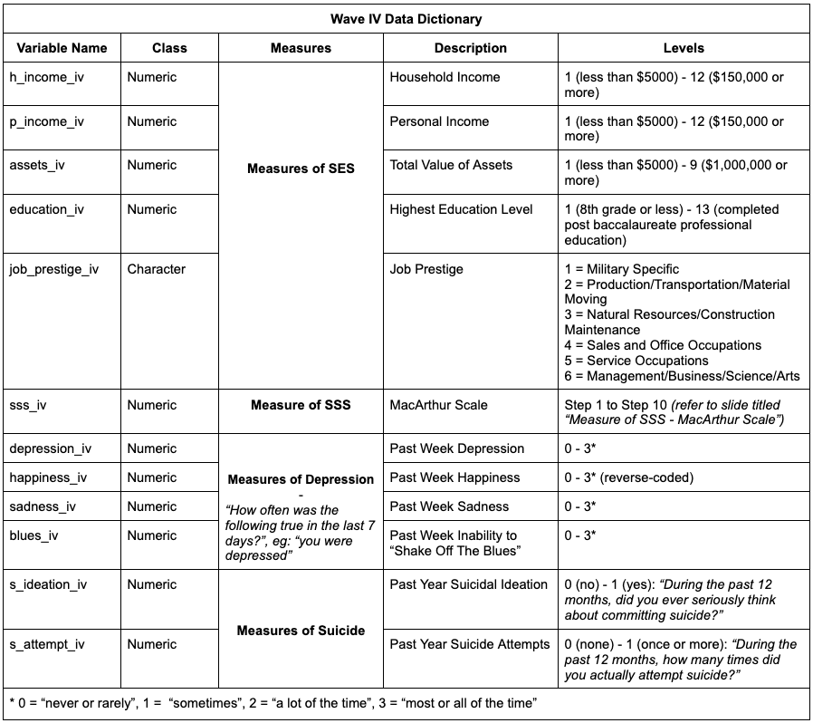

### 3.2.2 Cleaning The Data (Wave IV)

The variables used for our analysis have been renamed to represent the constructs being measured, as indicated by the authors of the original paper.

Additionally, any subject who skipped, refused to answer, or responded “don’t know” to any survey question used in our analysis was removed, along with subjects for whom data was missing or “NA”.

The personal income variable (`p_income_iv`) was recoded (`p_income_iv_rec`) to match the variable levels indicated by the authors of the original paper (as seen in the data dictionary in the previous slide).

The job prestige variable (`job_prestige_iv`) included Standard Occupational Classification (SOC) codes from the U.S. Department of Labor. Based on information provided by the authors (see **Appendix A**), the variable was recoded then classed as numeric (`job_prestige_iv_rec`).

Finally, the suicide attempts variable (`s_attempts_iv`) prompted participants to respond on a scale of 0 (none) to 4 (5 or more times) to the question, “During the past 12 months, how many times have you actually attempted suicide?” As per the authors’ methods, this variable was recoded (`s_attempts_iv_rec`) as a binary variable indicating whether or not the participant attempted suicide in the past 12 months (0 = zero attempts, 1 = one or more attempts)

### 3.2.3 Excerpt of Cleaned Data (Wave IV)

```r
# Selecting the variables to be used in our analysis
selected_vars_iv <- c("h4ec1", "h4ec2", "h4ec7", "h4ed2", "h4lm8",
                   "h4ec19", "h4mh22", "h4mh24", "h4mh26", "h4mh19",
                   "h4se1", "h4se2")
data_iv_vars <- data_iv[, selected_vars_iv]

# Renaming the variables used in our analysis
data_iv_vars <- data_iv_vars |>
  rename(h_income_iv = h4ec1,
         p_income_iv = h4ec2,
         assets_iv = h4ec7,
         education_iv = h4ed2,
         job_prestige_iv = h4lm8,
         sss_iv = h4ec19,
         depression_iv = h4mh22,
         happiness_iv = h4mh24,
         sadness_iv = h4mh26,
         blues_iv = h4mh19,
         s_ideation_iv = h4se1,
         s_attempts_iv = h4se2)

# Removing subjects who skipped, refused to answer, or responded "don't know"
# to questions, as well as any missing values from the dataset
data_iv_cleaned <- data_iv_vars |>
  filter(!(h_income_iv %in% c(96, 98)) &
           !(p_income_iv %in% c(9999996, 9999998)) &
           !(assets_iv %in% c(96, 98)) &
           !(education_iv %in% c(98)) &
           !(job_prestige_iv %in% c(9999995, 9999997, 9999998)) &
           !(sss_iv %in% c(96, 98)) &
           !(depression_iv %in% c(6)) &
           !(happiness_iv %in% c(6)) &
           !(sadness_iv %in% c(6)) &
           !(blues_iv %in% c(6)) &
           !(s_ideation_iv %in% c(6, 7, 8, ".")) &
           !(s_attempts_iv %in% c(6, 7, 8, ".")) &
           !is.na(s_ideation_iv) &
           !is.na(s_attempts_iv))

# Recoding personal income (`p_income_iv`) as the original paper's authors described
data_iv_cleaned <- data_iv_cleaned |>
  mutate(p_income_iv_rec = case_when(
    p_income_iv < 5000 ~ 1,
    p_income_iv >= 5000 & p_income_iv <= 9999 ~ 2,
    p_income_iv >= 10000 & p_income_iv <= 14999 ~ 3,
    p_income_iv >= 15000 & p_income_iv <= 19999 ~ 4,
    p_income_iv >= 20000 & p_income_iv <= 24999 ~ 5,
    p_income_iv >= 25000 & p_income_iv <= 29999 ~ 6,
    p_income_iv >= 30000 & p_income_iv <= 39999 ~ 7,
    p_income_iv >= 40000 & p_income_iv <= 49999 ~ 8,
    p_income_iv >= 50000 & p_income_iv <= 74999 ~ 9,
    p_income_iv >= 75000 & p_income_iv <= 99999 ~ 10,
    p_income_iv >= 100000 & p_income_iv <= 149999 ~ 11,
    p_income_iv >= 150000 ~ 12
  ))

# Recoding job prestige (`job_prestige_iv`) as the original paper's authors described
data_iv_cleaned <- data_iv_cleaned |>
  mutate(job_prestige_iv_rec = case_when(
    str_starts(job_prestige_iv, "11") ~ "6",
    str_starts(job_prestige_iv, "13") ~ "6",
    str_starts(job_prestige_iv, "15") ~ "6",
    str_starts(job_prestige_iv, "17") ~ "6",
    str_starts(job_prestige_iv, "19") ~ "6",
    str_starts(job_prestige_iv, "21") ~ "6",
    str_starts(job_prestige_iv, "23") ~ "6",
    str_starts(job_prestige_iv, "25") ~ "6",
    str_starts(job_prestige_iv, "27") ~ "6",
    str_starts(job_prestige_iv, "29") ~ "6",
    str_starts(job_prestige_iv, "31") ~ "6",
    str_starts(job_prestige_iv, "35") ~ "5",
    str_starts(job_prestige_iv, "39") ~ "5",
    str_starts(job_prestige_iv, "41") ~ "4",
    str_starts(job_prestige_iv, "43") ~ "4",
    str_starts(job_prestige_iv, "37") ~ "3",
    str_starts(job_prestige_iv, "45") ~ "3",
    str_starts(job_prestige_iv, "47") ~ "3",
    str_starts(job_prestige_iv, "49") ~ "3",
    str_starts(job_prestige_iv, "51") ~ "2",
    str_starts(job_prestige_iv, "53") ~ "2",
    str_starts(job_prestige_iv, "33") ~ "1"))

# Changing the variable class of `job_prestige_iv_rec` from chr (character) to dbl (numeric)
data_iv_cleaned$job_prestige_iv_rec <- as.numeric(data_iv_cleaned$job_prestige_iv_rec)

# Removing missing values from `job_prestige_iv_rec`
data_iv_cleaned <- data_iv_cleaned |>
  filter(!is.na(job_prestige_iv_rec))

# Recoding `s_attempts_iv` as the original paper's authors described
data_iv_cleaned <- data_iv_cleaned |>
  mutate(s_attempts_iv_rec = case_when(
    s_attempts_iv < 1 ~ 0,
    s_attempts_iv >= 1 & s_attempts_iv <= 4 ~ 1))
```

```r
# Excerpt of cleaned data
head(data_iv_cleaned)|>
  kableExtra::kbl(caption = "<b>Table 2</b> Depicting Excerpt of Cleaned Data (Wave IV)") |>
  kableExtra::kable_classic(full_width = F, html_font = "Cambria")|>
  kableExtra::kable_styling(font_size = 12) |>
  kableExtra::scroll_box(width = "80%", height = "300px")
```

**Table 2** Depicting Excerpt of Cleaned Data (Wave IV)

| h_income_iv | p_income_iv | assets_iv | education_iv | job_prestige_iv | sss_iv | depression_iv | happiness_iv | sadness_iv | blues_iv | s_ideation_iv | s_attempts_iv | p_income_iv_rec | job_prestige_iv_rec | s_attempts_iv_rec |
| --- | --- | --- | --- | --- | --- | --- | --- | --- | --- | --- | --- | --- | --- | --- |
| 5 | 23000 | 3 | 2 | 49-9099 | 5 | 0 | 3 | 1 | 0 | 1 | 0 | 5 | 3 | 0 |
| 6 | 27000 | 3 | 6 | 35-2011 | 6 | 0 | 3 | 0 | 0 | 0 | 0 | 6 | 5 | 0 |
| 9 | 32000 | 1 | 6 | 35-2011 | 5 | 0 | 2 | 0 | 0 | 0 | 0 | 7 | 5 | 0 |
| 9 | 5000 | 4 | 1 | 47-2021 | 3 | 0 | 2 | 1 | 0 | 0 | 0 | 2 | 3 | 0 |
| 9 | 19000 | 4 | 6 | 41-2031 | 5 | 0 | 3 | 0 | 0 | 0 | 0 | 4 | 4 | 0 |
| 11 | 40000 | 1 | 12 | 43-9199 | 6 | 0 | 2 | 1 | 0 | 0 | 0 | 8 | 4 | 0 |

### 3.2.4 Preparing the Data for Analysis (Wave IV) - SES and SSS

Socioeconomic Status (SES) was measured by assessing participants’ household income, personal income, combined assets, educational attainment, and job prestige. These five SES variables were each standardized, summed together, and re-standardized to create an SES composite variable with a mean of 0 and standard deviation of 1. Additionally, Subjective Social Status (SSS) must also be standardized to have a mean of 0 and standard deviation of 1.

```r
# Standardizing SES variables
data_iv_cleaned <- data_iv_cleaned |>
  mutate(h_income_z = scale(h_income_iv, center = TRUE, scale = TRUE),
         p_income_z = scale(p_income_iv_rec, center = TRUE, scale = TRUE),
         assets_z = scale(assets_iv, center = TRUE, scale = TRUE),
         education_z = scale(education_iv, center = TRUE, scale = TRUE),
         job_prestige_z = scale(job_prestige_iv_rec, center = TRUE, scale = TRUE))

# Composite SES score
z_scores_iv <- c("h_income_z", "p_income_z", "assets_z", "education_z", "job_prestige_z")

data_iv_cleaned <- data_iv_cleaned |>
  mutate(ses_m = var_score(data_iv_cleaned,
                           forward_items = z_scores_iv))

# Standardizing SES composite score
data_iv_cleaned <- data_iv_cleaned |>
  mutate(ses_m_z = scale(ses_m, center = TRUE, scale = TRUE))

# Standardizing SSS score
data_iv_cleaned <- data_iv_cleaned |>
  mutate(sss_z = scale(sss_iv, center = TRUE, scale = TRUE))
```

### 3.2.5 Preparing the Data for Analysis (Wave IV) - Depressive Symptoms

```r
# Composite depression score
dep_items_iv <- c("depression_iv", "sadness_iv", "blues_iv")

data_iv_cleaned <- data_iv_cleaned |>
  mutate(depression_iv_m = var_score(data_iv_cleaned,
                           forward_items = dep_items_iv,
                           reverse_items = c("happiness_iv"),
                           item_range = c(0, 3)))

# Standardizing depression composite score
data_iv_cleaned <- data_iv_cleaned |>
  mutate(depression_iv_m_z = scale(depression_iv_m, center = TRUE, scale = TRUE))
```

### 3.2.6 Summary Statistics (Wave IV)

```r
skim(data_iv_cleaned) |>
  kableExtra::kbl(caption = "<b>Table 3</b> Depicting Summary Statistics of Cleaned Data (Wave IV)") |>
  kableExtra::kable_classic(html_font = "Cambria")|>
  kableExtra::kable_styling(font_size = 12) |>
  kableExtra::scroll_box(width = "80%", height = "300px")
```

**Table 3** Depicting Summary Statistics of Cleaned Data (Wave IV)

| skim_type | skim_variable | n_missing | complete_rate | character.min | character.max | character.empty | character.n_unique | character.whitespace | numeric.mean | numeric.sd | numeric.p0 | numeric.p25 | numeric.p50 | numeric.p75 | numeric.p100 | numeric.hist |
| --- | --- | --- | --- | --- | --- | --- | --- | --- | --- | --- | --- | --- | --- | --- | --- | --- |
| character | job_prestige_iv | 0 | 1 | 7 | 7 | 0 | 439 | 0 | NA | NA | NA | NA | NA | NA | NA | NA |
| numeric | h_income_iv | 0 | 1 | NA | NA | NA | NA | NA | 8.037214e+00 | 2.557752e+00 | 1.0000000 | 7.0000000 | 9.0000000 | 1.000000e+01 | 1.200000e+01 | ▂▂▃▇▆ |
| numeric | p_income_iv | 0 | 1 | NA | NA | NA | NA | NA | 3.541208e+04 | 4.052567e+04 | 0.0000000 | 16000.0000000 | 30000.0000000 | 4.500000e+04 | 8.000000e+05 | ▇▁▁▁▁ |
| numeric | assets_iv | 0 | 1 | NA | NA | NA | NA | NA | 3.671926e+00 | 1.939869e+00 | 1.0000000 | 2.0000000 | 4.0000000 | 5.000000e+00 | 9.000000e+00 | ▆▇▃▃▁ |
| numeric | education_iv | 0 | 1 | NA | NA | NA | NA | NA | 5.798154e+00 | 2.183453e+00 | 1.0000000 | 4.0000000 | 6.0000000 | 7.000000e+00 | 1.300000e+01 | ▃▂▇▁▁ |
| numeric | sss_iv | 0 | 1 | NA | NA | NA | NA | NA | 4.982733e+00 | 1.673729e+00 | 1.0000000 | 4.0000000 | 5.0000000 | 6.000000e+00 | 1.000000e+01 | ▁▆▇▃▁ |
| numeric | depression_iv | 0 | 1 | NA | NA | NA | NA | NA | 3.724323e-01 | 6.623292e-01 | 0.0000000 | 0.0000000 | 0.0000000 | 1.000000e+00 | 3.000000e+00 | ▇▂▁▁▁ |
| numeric | happiness_iv | 0 | 1 | NA | NA | NA | NA | NA | 2.153319e+00 | 8.138249e-01 | 0.0000000 | 2.0000000 | 2.0000000 | 3.000000e+00 | 3.000000e+00 | ▁▃▁▇▇ |
| numeric | sadness_iv | 0 | 1 | NA | NA | NA | NA | NA | 5.599881e-01 | 6.588524e-01 | 0.0000000 | 0.0000000 | 0.0000000 | 1.000000e+00 | 3.000000e+00 | ▇▆▁▁▁ |
| numeric | blues_iv | 0 | 1 | NA | NA | NA | NA | NA | 2.974099e-01 | 6.178522e-01 | 0.0000000 | 0.0000000 | 0.0000000 | 0.000000e+00 | 3.000000e+00 | ▇▂▁▁▁ |
| numeric | s_ideation_iv | 0 | 1 | NA | NA | NA | NA | NA | 6.490030e-02 | 2.463865e-01 | 0.0000000 | 0.0000000 | 0.0000000 | 0.000000e+00 | 1.000000e+00 | ▇▁▁▁▁ |
| numeric | s_attempts_iv | 0 | 1 | NA | NA | NA | NA | NA | 1.309910e-02 | 1.374312e-01 | 0.0000000 | 0.0000000 | 0.0000000 | 0.000000e+00 | 3.000000e+00 | ▇▁▁▁▁ |
| numeric | p_income_iv_rec | 0 | 1 | NA | NA | NA | NA | NA | 6.015778e+00 | 2.789848e+00 | 1.0000000 | 4.0000000 | 7.0000000 | 8.000000e+00 | 1.200000e+01 | ▆▅▇▇▂ |
| numeric | job_prestige_iv_rec | 0 | 1 | NA | NA | NA | NA | NA | 4.498363e+00 | 1.301685e+00 | 1.0000000 | 4.0000000 | 5.0000000 | 6.000000e+00 | 6.000000e+00 | ▂▃▇▆▇ |
| numeric | s_attempts_iv_rec | 0 | 1 | NA | NA | NA | NA | NA | 1.041980e-02 | 1.015592e-01 | 0.0000000 | 0.0000000 | 0.0000000 | 0.000000e+00 | 1.000000e+00 | ▇▁▁▁▁ |
| numeric | h_income_z | 0 | 1 | NA | NA | NA | NA | NA | 0.000000e+00 | 1.000000e+00 | -2.7513280 | -0.4055177 | 0.3764191 | 7.673875e-01 | 1.549324e+00 | ▂▂▃▇▆ |
| numeric | p_income_z | 0 | 1 | NA | NA | NA | NA | NA | 0.000000e+00 | 1.000000e+00 | -1.7978679 | -0.7225406 | 0.3527868 | 7.112292e-01 | 2.144999e+00 | ▆▅▇▇▂ |
| numeric | assets_z | 0 | 1 | NA | NA | NA | NA | NA | 0.000000e+00 | 1.000000e+00 | -1.3773745 | -0.8618758 | 0.1691216 | 6.846204e-01 | 2.746615e+00 | ▆▇▃▃▁ |
| numeric | education_z | 0 | 1 | NA | NA | NA | NA | NA | 0.000000e+00 | 1.000000e+00 | -2.1975078 | -0.8235371 | 0.0924434 | 5.504336e-01 | 3.298375e+00 | ▃▂▇▁▁ |
| numeric | job_prestige_z | 0 | 1 | NA | NA | NA | NA | NA | 0.000000e+00 | 1.000000e+00 | -2.6875646 | -0.3828596 | 0.3853754 | 1.153610e+00 | 1.153610e+00 | ▂▂▁▅▇ |
| numeric | ses_m | 0 | 1 | NA | NA | NA | NA | NA | 0.000000e+00 | 3.184613e+00 | -10.0434078 | -2.1471312 | 0.0735884 | 2.157923e+00 | 9.817597e+00 | ▁▃▇▅▁ |
| numeric | ses_m_z | 0 | 1 | NA | NA | NA | NA | NA | 0.000000e+00 | 1.000000e+00 | -3.1537299 | -0.6742205 | 0.0231075 | 6.776092e-01 | 3.082823e+00 | ▁▃▇▅▁ |
| numeric | sss_z | 0 | 1 | NA | NA | NA | NA | NA | 0.000000e+00 | 1.000000e+00 | -2.3795564 | -0.5871517 | 0.0103165 | 6.077847e-01 | 2.997658e+00 | ▁▆▇▃▁ |
| numeric | depression_iv_m | 0 | 1 | NA | NA | NA | NA | NA | 2.076511e+00 | 2.210440e+00 | 0.0000000 | 0.0000000 | 1.0000000 | 3.000000e+00 | 1.200000e+01 | ▇▂▁▁▁ |
| numeric | depression_iv_m_z | 0 | 1 | NA | NA | NA | NA | NA | 0.000000e+00 | 1.000000e+00 | -0.9394107 | -0.9394107 | -0.4870121 | 4.177852e-01 | 4.489373e+00 | ▇▂▁▁▁ |

# 4 Data Analytic Strategy

Now that the data has been prepared for analysis, below is a visualization of the mediation analysis we will be reproducing. As a reminder, the current study will be reproducing the results of SSS mediating the cross-sectional relationship between SES and depression & suicidality at baseline in 2008 (Wave IV).

```r
library(DiagrammeR)
grViz(as.character("digraph mediation{
  graph [layout = dot, rankdir = LR, splines = line]

  node [shape = box,
  style = filled,
  fillcolor = white,
  width = 1.8,
  height = 0.8,
  margin = 0.2]

  X [label = 'Socioeconomic Status - SES (X)']
  M [label = 'Subjective Social Status - SSS (M)']
  Y [label = 'Depressive Symptoms and Suicidality (Y)']

  edge [color = black, penwidth = 2, arrowsize = 0.8]
  X -> M [label = 'a']
  M -> Y [label = 'b']
  X -> Y [label = 'c_prime']
}"))
```

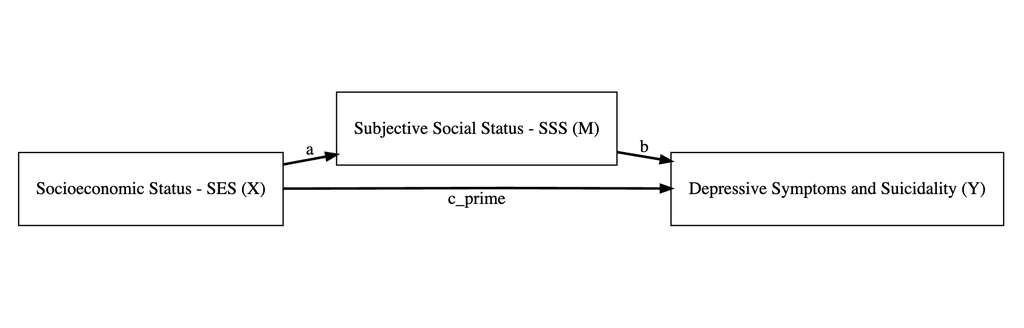

# 5 Data Analysis

## 5.1 Cross-Sectional Mediation Model - Depressive Symptoms

### 5.1.1 Reproduction Results

```r
m_med_1 <- "

sss_z ~ a * ses_m_z
depression_iv_m_z ~ cp * ses_m_z + b * sss_z

ab:= a*b
c := cp + ab
p_med:= ab/c
"

set.seed(1234)
fit1 <- sem(m_med_1, data = data_iv_cleaned, se = "bootstrap", bootstrap = 1000)
beepr::beep()
```

```r
parameterEstimates(fit1, ci = TRUE, level = 0.95, boot.ci.type = "perc", zstat = F)|>
  kableExtra::kbl(caption = "<b>Table 4</b> Reproduction Results of Cross-Sectional Mediation Analysis - Depressive Symptoms") |>
  kableExtra::kable_classic(html_font = "Cambria")|>
  kableExtra::kable_styling(font_size = 12) |>
  kableExtra::scroll_box(width = "80%", height = "300px")
```

**Table 4** Reproduction Results of Cross-Sectional Mediation Analysis - Depressive Symptoms

| lhs | op | rhs | label | est | se | ci.lower | ci.upper |
| --- | --- | --- | --- | --- | --- | --- | --- |
| sss_z | ~ | ses_m_z | a | 0.5014399 | 0.0153275 | 0.4699203 | 0.5317342 |
| depression_iv_m_z | ~ | ses_m_z | cp | -0.1217476 | 0.0197766 | -0.1626700 | -0.0835595 |
| depression_iv_m_z | ~ | sss_z | b | -0.1887644 | 0.0201131 | -0.2286634 | -0.1481833 |
| sss_z | ~~ | sss_z |  | 0.7483352 | 0.0201339 | 0.7133811 | 0.7908990 |
| depression_iv_m_z | ~~ | depression_iv_m_z |  | 0.9262219 | 0.0323688 | 0.8610617 | 0.9880869 |
| ses_m_z | ~~ | ses_m_z |  | 0.9997023 | 0.0000000 | 0.9997023 | 0.9997023 |
| ab | := | a*b | ab | -0.0946540 | 0.0105423 | -0.1153846 | -0.0738195 |
| c | := | cp+ab | c | -0.2164016 | 0.0177239 | -0.2524424 | -0.1826104 |
| p_med | := | ab/c | p_med | 0.4373996 | 0.0582277 | 0.3295113 | 0.5583174 |

### 5.1.2 Original Paper’s Results

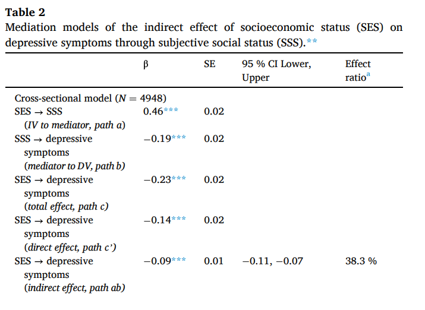

## 5.2 Cross-Sectional Mediation Model - Suicidal Ideation

### 5.2.1 Reproduction Results

```r
m_med_2 <- "

sss_z ~ a * ses_m_z
s_ideation_iv ~ cp * ses_m_z + b * sss_z

ab:= a*b
c := cp + ab
p_med:= ab/c
"

set.seed(1234)
fit2 <- sem(m_med_2, data = data_iv_cleaned, se = "bootstrap", bootstrap = 1000)
beepr::beep()
```

```r
parameterEstimates(fit2, ci = TRUE, level = 0.95, boot.ci.type = "perc", zstat = F)|>
  kableExtra::kbl(caption = "<b>Table 5</b> My Results of Cross-Sectional Mediation Analysis - Suicidal Ideation") |>
  kableExtra::kable_classic(html_font = "Cambria")|>
  kableExtra::kable_styling(font_size = 12) |>
  kableExtra::scroll_box(width = "80%", height = "300px")
```

**Table 5** My Results of Cross-Sectional Mediation Analysis - Suicidal Ideation

| lhs | op | rhs | label | est | se | ci.lower | ci.upper |
| --- | --- | --- | --- | --- | --- | --- | --- |
| sss_z | ~ | ses_m_z | a | 0.5014399 | 0.0153275 | 0.4699203 | 0.5317342 |
| s_ideation_iv | ~ | ses_m_z | cp | -0.0079176 | 0.0049428 | -0.0177355 | 0.0014009 |
| s_ideation_iv | ~ | sss_z | b | -0.0289877 | 0.0051936 | -0.0387453 | -0.0185216 |
| sss_z | ~~ | sss_z |  | 0.7483352 | 0.0201339 | 0.7133811 | 0.7908990 |
| s_ideation_iv | ~~ | s_ideation_iv |  | 0.0595554 | 0.0035747 | 0.0526958 | 0.0669065 |
| ses_m_z | ~~ | ses_m_z |  | 0.9997023 | 0.0000000 | 0.9997023 | 0.9997023 |
| ab | := | a*b | ab | -0.0145356 | 0.0026534 | -0.0196616 | -0.0092712 |
| c | := | cp+ab | c | -0.0224532 | 0.0045782 | -0.0317520 | -0.0135445 |
| p_med | := | ab/c | p_med | 0.6473730 | 0.1826110 | 0.3775050 | 1.0924020 |

### 5.2.2 Original Paper’s Results

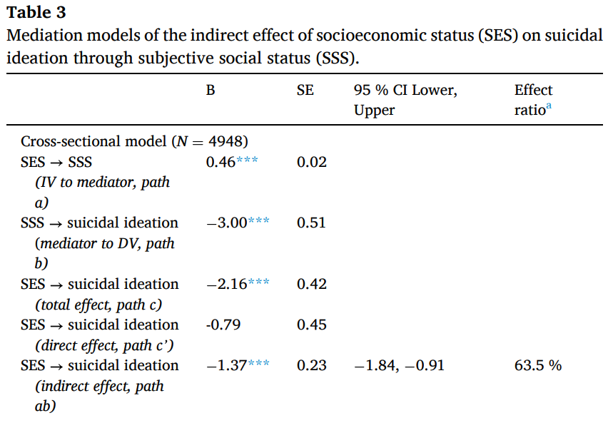

## 5.3 Cross-Sectional Mediation Model - Suicidal Attempts

### 5.3.1 Reproduction Results

```r
m_med_3 <- "

sss_z ~ a * ses_m_z
s_attempts_iv_rec ~ cp * ses_m_z + b * sss_z

ab:= a*b
c := cp + ab
p_med:= ab/c
"

set.seed(1234)
fit3 <- sem(m_med_3, data = data_iv_cleaned, se = "bootstrap", bootstrap = 1000)
beepr::beep()
```

```r
parameterEstimates(fit3, ci = TRUE, level = 0.95, boot.ci.type = "perc", zstat = F)|>
  kableExtra::kbl(caption = "<b>Table 6</b> My Results of Cross-Sectional Mediation Analysis - Suicide Attempts") |>
  kableExtra::kable_classic(html_font = "Cambria")|>
  kableExtra::kable_styling(font_size = 12) |>
  kableExtra::scroll_box(width = "80%", height = "300px")
```

**Table 6** My Results of Cross-Sectional Mediation Analysis - Suicide Attempts

| lhs | op | rhs | label | est | se | ci.lower | ci.upper |
| --- | --- | --- | --- | --- | --- | --- | --- |
| sss_z | ~ | ses_m_z | a | 0.5014399 | 0.0153472 | 0.4698895 | 0.5317503 |
| s_attempts_iv_rec | ~ | ses_m_z | cp | -0.0033697 | 0.0022987 | -0.0078407 | 0.0010554 |
| s_attempts_iv_rec | ~ | sss_z | b | -0.0028288 | 0.0016943 | -0.0063477 | 0.0003795 |
| sss_z | ~~ | sss_z |  | 0.7483352 | 0.0201108 | 0.7134393 | 0.7909399 |
| s_attempts_iv_rec | ~~ | s_attempts_iv_rec |  | 0.0102823 | 0.0017011 | 0.0070759 | 0.0137343 |
| ses_m_z | ~~ | ses_m_z |  | 0.9997023 | 0.0000000 | 0.9997023 | 0.9997023 |
| ab | := | a*b | ab | -0.0014185 | 0.0008513 | -0.0032245 | 0.0001841 |
| c | := | cp+ab | c | -0.0047882 | 0.0023671 | -0.0095169 | -0.0001804 |
| p_med | := | ab/c | p_med | 0.2962445 | 1.1837656 | -0.2683222 | 1.3122130 |

### 5.3.2 Original Paper’s Results

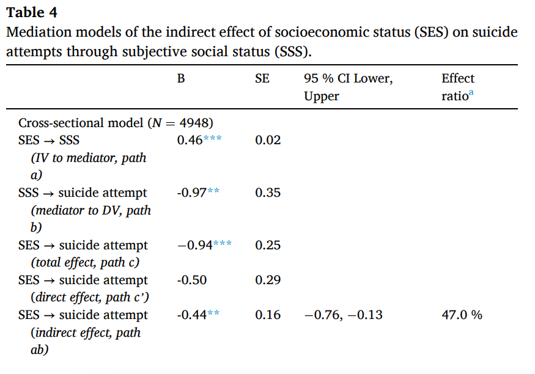

## 5.4 Results

Despite the fact that the reproduced parameter estimates of each mediation model do not closely resemble that of the original paper’s, the following statements from the original paper are upheld by the results of the reproduction analyses:

#### 5.4.0.1 SSS (M) as a mediator of the relationship between SES (X) and Depressive Symptoms (Y)

1. There is an effect of SES (X) on depressive symptoms (Y). Path `c` (the total effect) is significant.
2. There is an effect of SES (X) on SSS (M). Path `a` is significant.
3. There is an effect of SSS (M) on depressive symptoms (Y), controlling for SES (X). Path `b` is significant.
4. The effect of SES (X) on depressive symptoms (Y) is reduced significantly when SSS (M) is included in the model. Or in other words, there is a significant indirect effect `ab`.

#### 5.4.0.2 SSS (M) as a mediator of the relationship between SES (X) and Suicidal Ideation (Y)

1. There is an effect of SES (X) on suicidal ideation (Y). Path `c` (the total effect) is significant.
2. There is an effect of SES (X) on SSS (M). Path `a` is significant.
3. There is an effect of SSS (M) on suicidal ideation (Y), controlling for SES (X). Path `b` is significant.
4. The effect of SES (X) on suicidal ideation (Y) is reduced significantly when SSS (M) is included in the model. Or in other words, there is a significant indirect effect `ab`.

#### 5.4.0.3 SSS (M) as a mediator of the relationship between SES (X) and Suicide Attempts (Y)

1. There is an effect of SES (X) on suicide attempts (Y). Path `c` (the total effect) is significant.
2. There is an effect of SES (X) on SSS (M). Path `a` is significant.

> **Results from my reproduction that differ from the results of the original paper**
3. There is NO effect of SSS (M) on suicide attempts (Y), controlling for SES (X). Path `b` is NOT significant.
4. The effect of SES (X) on suicide attempts (Y) is NOT reduced significantly when SSS (M) is included in the model. Or in other words, there is NO significant indirect effect `ab`.

# 6 Reflection on Reproduction: Cross-Sectional Mediation Models

The values obtained through the reproduction mediation analyses somewhat resembled that of the results of the original paper. But why weren’t they exactly the same?

1. **Covariates**: The original paper included age, sex, marital status and race as covariates in their analyses of the Wave IV data. However, this author elected not to include covariates in my model so as to not overcomplicate the analyses, as well as due to time constraints.
2. **Sample sizes and missing data**: Because the authors of the original study did not mention how they dealt with missing values in the dataset, this author elected to remove all subjects who were missing values from any of the variables central to our analyses, along with values that indicated the participant skipped the question, or responded with “don’t know”. Thus, the current study yielded a much smaller sample size (N = 3359) compared to the sample size of the original paper (N = 4948).
3. **Variable grouping and recoding**: This author believes that the reproduction results may not closely resemble that of the original paper’s in part because there were no clear instructions on how to recode the job prestige variable into the categories outlined by the original authors.
4. **Linear probability models**: The original authors used linear probability models to estimate the relationship between SES, SSS, and suicidal ideation and suicide attempts. They then scaled regression coefficients to indicate the percentage point changes in suicidal ideation and suicide attempts associated with a standard deviation increase in SES or SSS. This author was not able to do this.
5. **Survey weights and clustering**: The original authors applied cross-sectional and longitudinal survey weights. They also took into account the complex survey design of NLSAAH Add Health, including clustering at the school level, when estimating standard errors. This author was not able to do this.
6. **Wave V Data**: This author was not able to conduct any prospective or longitudinal model analyses due to time constraints.

# 7 Conclusion

This reproduction study sought to replicate a portion of Madigan and Daly’s (2023) findings on the mediating effect of Subjective Social Status (SSS) on the relationship between Socioeconomic Status (SES) and depressive symptoms, suicidal ideation, and suicide attempts using cross-sectional data from Wave IV of the NLSAAH public-use dataset.

The reproduced analyses confirmed that SSS significantly mediates the relationship between SES and both depressive symptoms and suicidal ideation. These findings support the original authors’ conclusions and reinforce the notion that individuals’ perceived position within the social hierarchy contributes meaningfully to mental health outcomes, beyond objective measures of SES alone.

However, unlike the original study, this reproduction did not find a significant mediating effect of SSS in the relationship between SES and suicide attempts. This discrepancy may be attributable to methodological differences, including the exclusion of covariates, the use of a smaller sample, simplified coding of job prestige, and the inability to incorporate survey weights or linear probability models.

Despite these limitations, this reproduction adds credibility to the original study’s core claims and highlights the importance of considering both objective and subjective indicators of social standing when examining mental health disparities. The results of this analysis emphasizes the value of reproducibility in psychology and contributes to a growing culture of transparency in research.

# 8 Appendices

## 8.1 Appendix A

**Recoding `job_prestige_iv`**

The authors of the original paper wrote, “job prestige was measured by coding job descriptions into a detailed ranking that including 6 broad descriptions (1 = Military Specific, 2 = Production/Transportation/Material Moving, 3 = Natural Resources/Construction Maintenance, 4 = Sales and Office Occupations, 5 = Service Occupations, and 6 = Management/Business/Science/Arts)”.

However, they did not provide any information as to which Standard Occupational Classification (SOC) codes belonged to which description. Below is my best estimation as to which SOC code belongs to which description:

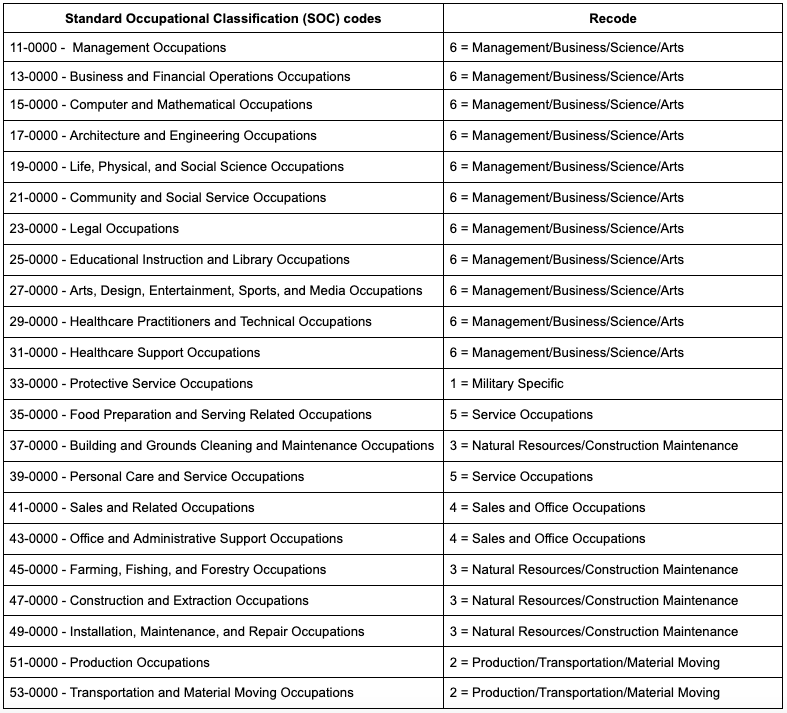

# 9 Citations

> Centers for Disease Control and Prevention. (2024a). *Suicide Risk Is Tied to Local Economic and Social Conditions*. Vital Signs. https://www.cdc.gov/vitalsigns/prevent-suicide/index.html

> Centers for Disease Control and Prevention. (2024b). *Suicide data and statistics*. Suicide Prevention. https://www.cdc.gov/suicide/facts/data.html

> Conerly, T. R., Holmes, K., & Tamang, A. L. (2021). 9.1 What Is Social Stratification? In *Introduction to Sociology 3e*. essay, OpenStax. Retrieved from https://openstax.org/books/introduction-sociology-3e/pages/9-1-what-is-social-stratification

> Jespersen, A., Madden, R., Whalley, H. C., Reynolds, R., Lawrie, S. M., McIntosh, A. M., & Iveson, M. (2023). *Socioeconomic Status and Depression – A Systematic Review*. medRxiv. https://doi.org/10.1101/2023.12.04.23299380

> Madigan, A., & Daly, M. (2023). *Socioeconomic status and depressive symptoms and suicidality: The role of subjective social status*. Journal of Affective Disorders, 326, 36–43. https://doi.org/10.1016/j.jad.2023.01.078

> Substance Abuse and Mental Health Services Administration. (2022). *Key substance use and mental health indicators in the United States: Results from the 2021 National Survey on Drug Use and Health* (HHS Publication No. PEP22-07-01-005, NSDUH Series H-57). Center for Behavioral Health Statistics and Quality, Substance Abuse and Mental Health Services Administration. https://www.samhsa.gov/data/report/2021-nsduh-annual-national-report